# Week 9: Factors & Pull Requests

Miscellany

Joe Nese

University of Oregon  
Fall 2025

# Thankful for you

extra credit

## Homework Review

Homework 9

# Factors & Pull Requests

Week 9

## Agenda

- Final Project Review
- Discuss factors and factor re-leveling
- Walk through a pull request (PR)

**Overall Purpose**

- Understand factors and how to manipulate them
- Understand how to complete a pull request (PR)

## Your code!

[figure not shown]

# Final Project

## Final Project - Data Prep Script

- Expected to be a work in progress
- Provided to your peers so they can learn from you as much as you can learn from their feedback

**Peer Review**

- Understand the purpose of the exercise
- Conducted as a professional product
- Should be **very** encouraging
- Zero tolerance policy for inappropriate comments

## Final Project – Presentation

- Groups are expected to present for about **15-20 minutes** (split evenly among members)
- Group order randomly assigned

## Final Project – Presentation

**Presentation cover the following:**

- Share your journey (everyone, at least for a minute or two)
- Discuss challenges you had along the way
- Celebrate your successes
- Discuss challenges you are still facing
- Discuss substantive findings
- Show off your cool figures!
- Discuss next `R` hurdle you want to address

## Final Project – Paper

- Quarto document
  - Abstract, Intro, Methods, Results, Discussion, References
  - Should be brief: 3,500 words max
- No code displayed - should look similar to a manuscript being submitted for publication
- Include at least 1 table
- Include at least 2 plots
- Should be fully open, reproducible, and housed on GitHub
  - I should be able to clone your repository, open the R Studio Project, and reproduce the full manuscript (by rendering the quarto doc)

## Final Project

The following functions:

- `pivot_longer()`
- `mutate()`
- `select()`
- `filter()`
- `pivot_wider()`
- `group_by()`
- `summarize()`

## Scoring Rubric

Check the [syllabus](https://jnese.github.io/intro-DS-R_fall-2025/syllabus.html) for the scoring rubrics for:

- [Presentation](https://jnese.github.io/intro-DS-R_fall-2025/syllabus.html#final-project-presentation-25-points) and
- [Final Paper](https://jnese.github.io/intro-DS-R_fall-2025/syllabus.html#final-paper-110)

# Factors

just the basics

## When do we really want factors?

Generally two reasons to declare a factor

1. Only finite number of categories
   - treatment/control
   - income categories
   - performance levels
   - months
   - etc.
2. Use in modeling

## Creating factors

Imagine you have a vector of months

```r
months_4 <- c("Dec", "Apr", "Jan", "Mar")
```

We could store this as a string, but there are issues with this:

- There are only 12 possible months
  - factors will help us weed out values that don’t conform to our predefined levels, which helps safeguard against typos, etc.
- You can’t sort this vector in a meaningful way
  - default is alphabetic sorting

```r
sort(months_4)
```

```
[1] "Apr" "Dec" "Jan" "Mar"
```

## Define it as a `factor()`

And hand enter the order of the levels

```r
months_4 <- factor(months_4, levels = c("Jan", "Feb", "Mar", "Apr", "May", "Jun", "Jul", "Aug", "Sep", "Oct", "Nov", "Dec"))
months_4
```

```
[1] Dec Apr Jan Mar
Levels: Jan Feb Mar Apr May Jun Jul Aug Sep Oct Nov Dec
```

Now we can sort

```r
sort(months_4)
```

```
[1] Jan Mar Apr Dec
Levels: Jan Feb Mar Apr May Jun Jul Aug Sep Oct Nov Dec
```

## Accessing and modifying levels

Use the `levels()` function

```r
levels(months_4)
```

```
 [1] "Jan" "Feb" "Mar" "Apr" "May" "Jun" "Jul" "Aug" "Sep" "Oct" "Nov" "Dec"
```

## Provides an error check of sorts

```r
months_4[5] <- "Jam"
```

```r
months_4
```

```
[1] Dec  Apr  Jan  Mar  <NA>
Levels: Jan Feb Mar Apr May Jun Jul Aug Sep Oct Nov Dec
```

## What if we don’t specify levels?

If you define a factor without specifying the levels, it will assign them alphabetically

```r
mnths <- factor(c("Dec", "Apr", "Jan", "Mar"))
```

```
[1] Dec Apr Jan Mar
Levels: Apr Dec Jan Mar
```

## [`{forcats}`](https://forcats.tidyverse.org/)

[figure not shown]

- When working with factors, we can use the `{forcats}` package
  - `for cat`egorical variables
  - anagram of factors
  - best package name ever?
- Part of the `{tidyverse}` so should be good to go
- All functions start with `fct_`
  - use the autofill in RStudio

## Change level order – `fct_inorder()`

By the order in which they first appear

```r
(simpsons <- factor(c("Homer", "Marge", "Bart", "Lisa", "Maggie")))
```

```
[1] Homer  Marge  Bart   Lisa   Maggie
Levels: Bart Homer Lisa Maggie Marge
```

```r
simpsons |>
  sort()
```

```
[1] Bart   Homer  Lisa   Maggie Marge
Levels: Bart Homer Lisa Maggie Marge
```

## Change level order – `fct_inorder()`

By the order in which they first appear

```r
(simpsons <- factor(c("Homer", "Marge", "Bart", "Lisa", "Maggie")))
```

```
[1] Homer  Marge  Bart   Lisa   Maggie
Levels: Bart Homer Lisa Maggie Marge
```

```r
simpsons |>
  fct_inorder() |>
  sort()
```

```
[1] Homer  Marge  Bart   Lisa   Maggie
Levels: Homer Marge Bart Lisa Maggie
```

## Change level order – `fct_infreq()`

By number of observations with each level (largest first)

```r
c("b", "b", "c", "a", "a", "a") |>
    fct_infreq()
```

```
[1] b b c a a a
Levels: a b c
```

This can be **especially** useful for plotting

```r
ggplot(aes(x, fct_infreq(y))
```

## Investigate factors

- `{tidyverse}` gives you convenient way to evaluate factors
  - `count()`
  - `geom_bar()` or `geom_col())` with `{ggplot2}`
- But don’t forget about the base function `unique()`
  - e.g., `unique(df$factor_variable)`

## General Social Survey (GSS)

```r
forcats::gss_cat
```

```
# A tibble: 21,483 × 9
    year marital         age race  rincome        partyid    relig denom tvhours
   <int> <fct>         <int> <fct> <fct>          <fct>      <fct> <fct>   <int>
 1  2000 Never married    26 White $8000 to 9999  Ind,near … Prot… Sout…      12
 2  2000 Divorced         48 White $8000 to 9999  Not str r… Prot… Bapt…      NA
 3  2000 Widowed          67 White Not applicable Independe… Prot… No d…       2
 4  2000 Never married    39 White Not applicable Ind,near … Orth… Not …       4
 5  2000 Divorced         25 White Not applicable Not str d… None  Not …       1
 6  2000 Married          25 White $20000 - 24999 Strong de… Prot… Sout…      NA
 7  2000 Never married    36 White $25000 or more Not str r… Chri… Not …       3
 8  2000 Divorced         44 White $7000 to 7999  Ind,near … Prot… Luth…      NA
 9  2000 Married          44 White $25000 or more Not str d… Prot… Other       0
10  2000 Married          47 White $25000 or more Strong re… Prot… Sout…       3
# ℹ 21,473 more rows
```

```r
gss_cat |>
  count(partyid)
```

```
# A tibble: 10 × 2
   partyid                n
   <fct>              <int>
 1 No answer            154
 2 Don't know             1
 3 Other party          393
 4 Strong republican   2314
 5 Not str republican  3032
 6 Ind,near rep        1791
 7 Independent         4119
 8 Ind,near dem        2499
 9 Not str democrat    3690
10 Strong democrat     3490
```

```r
levels(gss_cat$partyid)
```

```
 [1] "No answer"          "Don't know"         "Other party"
 [4] "Strong republican"  "Not str republican" "Ind,near rep"
 [7] "Independent"        "Ind,near dem"       "Not str democrat"
[10] "Strong democrat"
```

```r
unique(gss_cat$partyid)
```

```
 [1] Ind,near rep       Not str republican Independent        Not str democrat
 [5] Strong democrat    Ind,near dem       Strong republican  Other party
 [9] No answer          Don't know
10 Levels: No answer Don't know Other party ... Strong democrat
```

How many `unique` categories are there (if you have a lot)?

```r
length(unique(gss_cat$partyid))
```

```
[1] 10
```

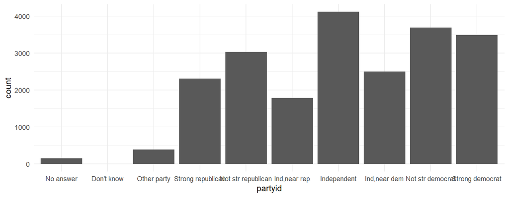

```r
ggplot(gss_cat, aes(partyid)) +
    geom_bar()
```

```r
ggplot(gss_cat, aes(fct_infreq(partyid))) +
    geom_bar()
```

ggplot(gss_cat, aes(fct_infreq(partyid))) +  
geom_bar()

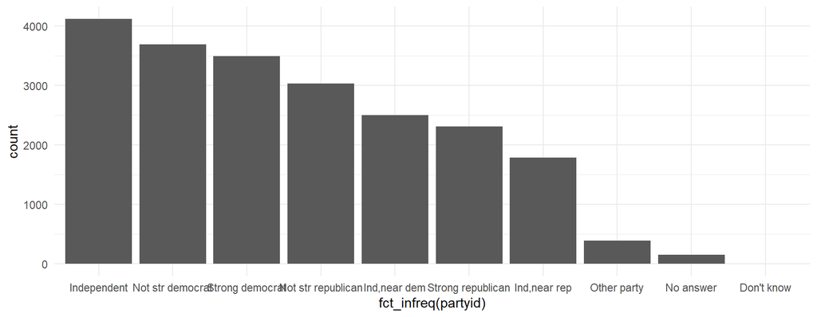

## Change level order – `fct_relevel()`

Change level order by hand, or move any number of levels to any location

- *probably one I use most*

```r
fct_relevel(variable_name,
            "first_level",
            "second_level",
            "third_level",
            ...)
```

```r
fct_relevel(variable_name,
            "fourth_level",
            after = 3)
```

```r
set.seed(3000)
tibble(
 month = c("Jan", "Feb", "Mar", "Apr", "May", "Jun", "Sep", "Oct", "Nov", "Dec"),
 suspensions = sample(c(5:75), size = 10)
)
```

```
# A tibble: 10 × 2
   month suspensions
   <chr>       <int>
 1 Jan            19
 2 Feb            51
 3 Mar            61
 4 Apr            14
 5 May            25
 6 Jun            27
 7 Sep            15
 8 Oct            21
 9 Nov             7
10 Dec            59
```

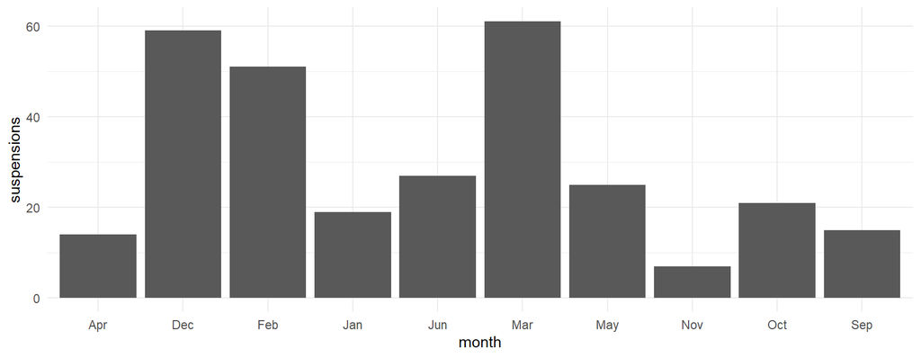

```r
set.seed(3000)
tibble(
 month = c("Jan", "Feb", "Mar", "Apr", "May", "Jun", "Sep", "Oct", "Nov", "Dec"),
 suspensions = sample(c(5:75), size = 10)
) |>
  ggplot(aes(month, suspensions)) +
  geom_col()
```

default alphabetical order

```r
set.seed(3000)
tibble(
 month = c("Jan", "Feb", "Mar", "Apr", "May", "Jun", "Sep", "Oct", "Nov", "Dec"),
 suspensions = sample(c(5:75), size = 10)
) |>
  mutate(month = fct_relevel(month,
                    "Sep", "Oct", "Nov", "Dec", "Jan", "Feb", "Mar", "Apr", "May"))
```

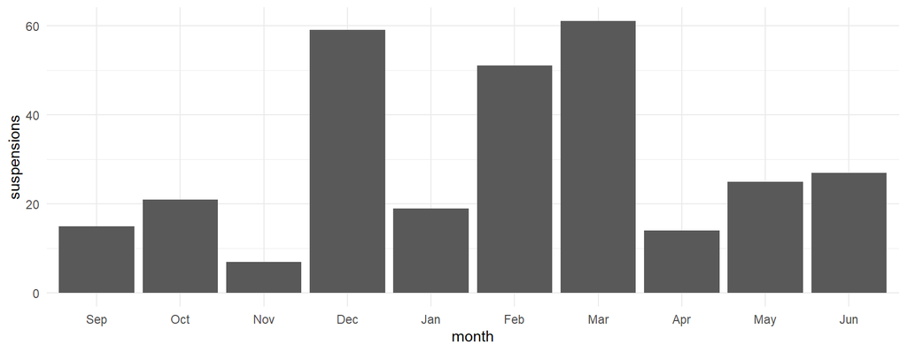

```r
set.seed(3000)
tibble(
 month = c("Jan", "Feb", "Mar", "Apr", "May", "Jun", "Sep", "Oct", "Nov", "Dec"),
 suspensions = sample(c(5:75), size = 10)
) |>
  mutate(month = fct_relevel(month,
                    "Sep", "Oct", "Nov", "Dec", "Jan", "Feb", "Mar", "Apr", "May")) |>
  ggplot(aes(month, suspensions)) +
  geom_col()
```

custom order

## Change level order – `fct_reorder()`

Reorder according to another variable

```r
(relig_summary <- gss_cat |>
  group_by(relig) |>
  summarise(tvhours = mean(tvhours, na.rm = TRUE),
            n = n()))
```

```
# A tibble: 15 × 3
   relig                   tvhours     n
   <fct>                     <dbl> <int>
 1 No answer                  2.72    93
 2 Don't know                 4.62    15
 3 Inter-nondenominational    2.87   109
 4 Native american            3.46    23
 5 Christian                  2.79   689
 6 Orthodox-christian         2.42    95
 7 Moslem/islam               2.44   104
 8 Other eastern              1.67    32
 9 Hinduism                   1.89    71
10 Buddhism                   2.38   147
11 Other                      2.73   224
12 None                       2.71  3523
13 Jewish                     2.52   388
14 Catholic                   2.96  5124
15 Protestant                 3.15 10846
```

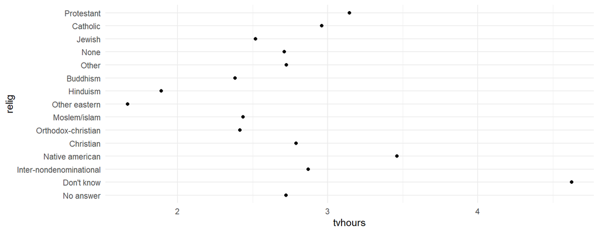

```r
ggplot(relig_summary, aes(tvhours, relig)) +
  geom_point()
```

## `mutate()` the factor reorder

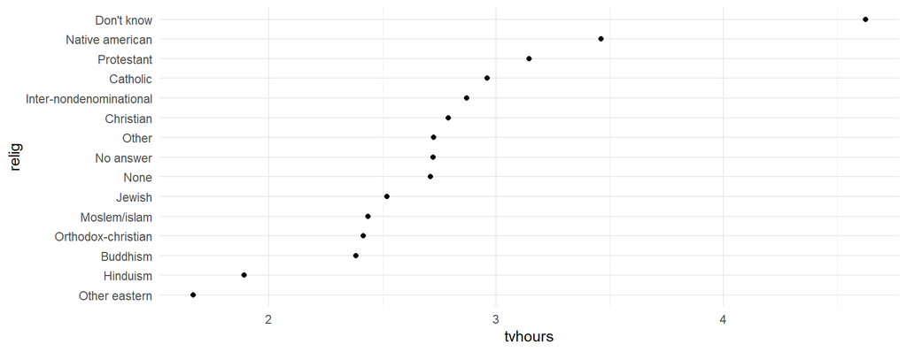

```r
relig_summary |>
  mutate(relig = fct_reorder(relig, tvhours)) |>
  ggplot(aes(tvhours, relig)) +
  geom_point()
```

## Or reorder within `ggplot()`

```r
ggplot(relig_summary, aes(tvhours, fct_reorder(relig, tvhours))) +
  geom_point()
```

fct_reorder(relig, tvhours))

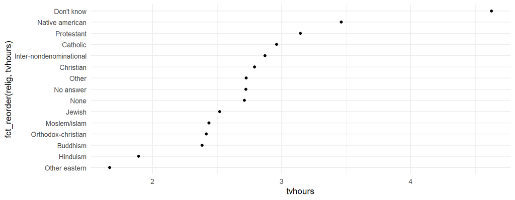

## Quick aside for error bars

```r
(relig_summary_eb <- gss_cat |>
  group_by(relig) |>
  summarise(tvhours_mean = mean(tvhours, na.rm = TRUE),
            tvhours_se   = sqrt(var(tvhours, na.rm = TRUE) /
                                  length(na.omit(tvhours))),
            n = n()))
```

```
# A tibble: 15 × 4
   relig                   tvhours_mean tvhours_se     n
   <fct>                          <dbl>      <dbl> <int>
 1 No answer                       2.72     0.326     93
 2 Don't know                      4.62     3.01      15
 3 Inter-nondenominational         2.87     0.363    109
 4 Native american                 3.46     1.13      23
 5 Christian                       2.79     0.126    689
 6 Orthodox-christian              2.42     0.355     95
 7 Moslem/islam                    2.44     0.269    104
 8 Other eastern                   1.67     0.449     32
 9 Hinduism                        1.89     0.197     71
10 Buddhism                        2.38     0.235    147
11 Other                           2.73     0.203    224
12 None                            2.71     0.0590  3523
13 Jewish                          2.52     0.151    388
14 Catholic                        2.96     0.0453  5124
15 Protestant                      3.15     0.0360 10846
```

## Quick aside for error bars

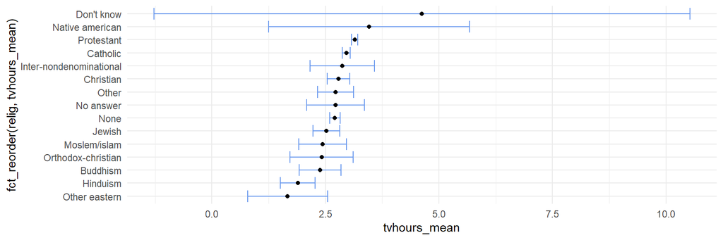

```r
ggplot(relig_summary_eb,
       aes(tvhours_mean, fct_reorder(relig, tvhours_mean))) +
  geom_errorbarh(aes(xmin = tvhours_mean - 1.96 * tvhours_se,
                     xmax = tvhours_mean + 1.96 * tvhours_se),
                 color = "cornflowerblue") +
  geom_point()
```

## Modifying factor levels – `fct_recode()`

Make modifying factors more explicit

`fct_recode(var_name,`

`"new level" = "old level"...`

```r
gss_cat |>
  mutate(partyid = fct_recode(partyid,
    "Republican, strong" = "Strong republican",
    "Republican, weak" = "Not str republican",
    "Independent, near rep" = "Ind, near rep",
    "Independent, near dem" = "Ind, near dem",
    "Democrat, weak" = "Not str democrat",
    "Democrat, strong" = "Strong democrat")) |>
  count(partyid)
```

## Collapsing levels – `fct_recode()`

`fct_recode()` can also be used to collapse levels easily

```r
gss_cat |>
  mutate(partyid = fct_recode(partyid,
    "Republican"  = "Strong republican",
    "Republican"  = "Not str republican",
    "Independent" = "Ind,near rep",
    "Independent" = "Ind,near dem",
    "Democrat"    = "Not str democrat",
    "Democrat"    = "Strong democrat",
    "Other"       = "No answer",
    "Other"       = "Don't know",
    "Other"       = "Other party")) |>
  count(partyid)
```

```
# A tibble: 4 × 2
  partyid         n
  <fct>       <int>
1 Other         548
2 Republican   5346
3 Independent  8409
4 Democrat     7180
```

## Collapsing levels – `fct_collapse()`

`fct_collapse()` is one of the more useful functions in `{forcats}`

- Collapse all categories into `Republican`, `Democrat`, `Independent`, or `Other`

```r
gss_cat |>
  mutate(partyid = fct_collapse(partyid,
        Other = c("No answer", "Don't know", "Other party"),
        Rep = c("Strong republican", "Not str republican"),
        Ind = c("Ind,near rep", "Independent", "Ind,near dem"),
        Dem = c("Not str democrat", "Strong democrat")
  )) |>
  count(partyid)
```

```
# A tibble: 4 × 2
  partyid     n
  <fct>   <int>
1 Other     548
2 Rep      5346
3 Ind      8409
4 Dem      7180
```

## Collapsing levels – `fct_lump_?()`

`fct_lump_?()` – “lump” a bunch of categories together

**`fct_lump_n(factor_variable, n)`**

lumps all levels except for the `n` most frequent (or least frequent if `n` < 0) into “Other” level

**`fct_lump_min(factor_variable, min)`**

lumps levels that appear fewer than `min` times

**`fct_lump_prop(factor_variable, prop)`**

lumps levels that appear in fewer `prop` $\times$ `n` times

## Collapsing levels – `fct_lump_n()`

Collapse to `n = 9` religious groups: top 8 groups plus “Other”

```r
gss_cat |>
  mutate(rel = fct_lump_n(relig, 9)) |>
  count(rel) |>
  arrange(rel)
```

```
# A tibble: 9 × 2
  rel                         n
  <fct>                   <int>
1 Inter-nondenominational   109
2 Christian                 689
3 Moslem/islam              104
4 Buddhism                  147
5 None                     3523
6 Jewish                    388
7 Catholic                 5124
8 Protestant              10846
9 Other                     553
```

## Collapsing levels – `fct_lump_min()`

Collapse to all religious groups that appear less than `min = 200` into `Other`

```r
gss_cat |>
  mutate(rel = fct_lump_min(relig, min = 200)) |>
  count(rel)
```

```
# A tibble: 6 × 2
  rel            n
  <fct>      <int>
1 Christian    689
2 None        3523
3 Jewish       388
4 Catholic    5124
5 Protestant 10846
6 Other        913
```

## Collapsing levels – `fct_lump_prop()`

Collapse to all religious groups that appear less than `prop = 10%` into `Other`

```r
gss_cat |>
  mutate(rel = fct_lump_prop(relig, prop = .10)) |>
  count(rel)
```

```
# A tibble: 4 × 2
  rel            n
  <fct>      <int>
1 None        3523
2 Catholic    5124
3 Protestant 10846
4 Other       1990
```

## Missing levels

```r
levels(gss_cat$race)
```

```
[1] "Other"          "Black"          "White"          "Not applicable"
```

```r
gss_cat |>
  count(race)
```

```
# A tibble: 3 × 2
  race      n
  <fct> <int>
1 Other  1959
2 Black  3129
3 White 16395
```

```r
table(gss_cat$race)
```

```
         Other          Black          White Not applicable
          1959           3129          16395              0
```

## Missing levels

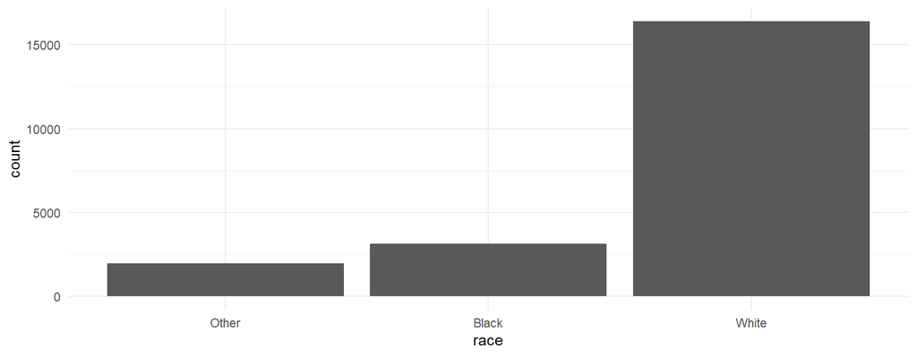

```r
ggplot(gss_cat, aes(race)) +
    geom_bar()
```

## Missing levels

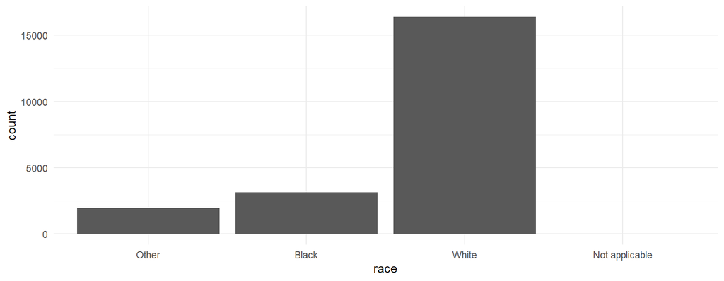

```r
ggplot(gss_cat, aes(race)) +
    geom_bar() +
    scale_x_discrete(drop = FALSE)
```

## Review

**`fct_inorder()`**

By the order in which they first appear

**`fct_infreq()`**

By number of observations with each level (largest first)

**`fct_relevel()`**

Change level order by hand, or move any number of levels to any location

**`fct_reorder()`**

Change level order according to another variable

**`fct_recode()`**

Recode levels into new named levels

**`fct_collapse()`**

Collapse many levels into fewer levels

**`fct_lump_?()`**

Recode all levels into “*Other*”:

`fct_lump_n()` - except for the `n` most frequent

`fct_lump_min()` - that appear fewer than `min` times

`fct_lump_prop()` - that appear less than `prop`%

# Revisiting git

## Let’s revisit git

Talk with neighbor. What do these terms mean?

Talk about them in the order you would encounter them in your workflow

- clone
- pull
- stage
- commit
- push
- repo
- remote

`03:00`

# Pull Requests

## Peer Review of Data Prep Script

Expectations

Feedback:

1. Note at least 3 areas of strength
2. Note at least 1 thing you learned from reviewing their script
3. Note at least 1 and no more than 3 areas for improvement

Making your code publicly available can feel daunting

- The purpose of this portion of the final project is to help us all learn from each other
- We are all learning
  - Be constructive in your feedback
  - Be kind
- Under no circumstances will negative comments be tolerated
  - Any comments that could be perceived as negative, and outside the scope of the code, will result in an immediate score of zero

## Peer Review GitHub Process

1. Locate GitHub repo of assigned peer to review
2. Fork the repo
3. Clone the repo
4. Provide script feedback
   1. edit the .qmd file directly
   2. edit code
   3. provide comments in code and/or text (`Ctrl/Command + Shift + C`)
5. commit & push!
6. Create Pull Request (PR)
- Write brief summary uisng `markdown` of the PR that includes
  - >= 3 strengths
  - >= 1 thing you learned
  - 1 to 3 three areas of improvement

## 1. Locate GitHub repo of assigned peer to review

| Student | Repo to Review | File to Review |
| --- | --- | --- |
| Kyla Brannigan | https://github.com/Febelin/Final_project | draft_data_preparation_script.qmd |
| Erika Davis | https://github.com/jjmarshalluo/final_project | final_project qmd.qmd |
| Cheyna Warner | https://github.com/XinyuWangLily/EDLD-651_Final-Project | EDLD_651_Final_Project.html |
| Steven McIntyre | https://github.com/skiros101/EDLD651_Final-Project | edld651_sk_okm_cs.qmd |
| Maritza Ruiz | https://github.com/Febelin/Final_project | draft_data_preparation_script.qmd |
| Sara Kiros | https://github.com/XinyuWangLily/EDLD-651_Final-Project | EDLD_651_Final_Project.html |
| Ohnmar Min | https://github.com/jjmarshalluo/final_project | final_project qmd.qmd |
| Chen Su | https://github.com/Febelin/Final_project | draft_data_preparation_script.qmd |
| Dodjivi Amekoudji | https://github.com/stmii/EDLD_651_Final_Project | final_proj.qmd |
| Emily Lang | https://github.com/skiros101/EDLD651_Final-Project | edld651_sk_okm_cs.qmd |
| Jessica Marshall | https://github.com/kylabrannigan/EDLD651_final_project | EDLD651_final_project.qmd |
| Kat Vrotsos | https://github.com/stmii/EDLD_651_Final_Project | final_proj.qmd |
| Febe Lin | https://github.com/kylabrannigan/EDLD651_final_project | EDLD651_final_project.qmd |
| James Phillips | https://github.com/jjmarshalluo/final_project | final_project qmd.qmd |
| Ramtin Ranjpour | https://github.com/XinyuWangLily/EDLD-651_Final-Project | EDLD_651_Final_Project.html |
| Sophie Hartford | https://github.com/skiros101/EDLD651_Final-Project | edld651_sk_okm_cs.qmd |
| Everett Mahaffy | https://github.com/jjmarshalluo/final_project | final_project qmd.qmd |
| Xinyu Wang | https://github.com/kylabrannigan/EDLD651_final_project | EDLD651_final_project.qmd |

|  | Student | Repo to Review | File to Review |
| --- | --- | --- | --- |
| 1 | Kyla Brannigan | https://github.com/Febelin/Final_project | draft_data_preparation_script.qmd |
| 2 | Erika Davis | https://github.com/jjmarshalluo/final_project | final_project qmd.qmd |
| 3 | Cheyna Warner | https://github.com/XinyuWangLily/EDLD-651_Final-Project | EDLD_651_Final_Project.html |
| 4 | Steven McIntyre | https://github.com/skiros101/EDLD651_Final-Project | edld651_sk_okm_cs.qmd |
| 5 | Maritza Ruiz | https://github.com/Febelin/Final_project | draft_data_preparation_script.qmd |
| 6 | Sara Kiros | https://github.com/XinyuWangLily/EDLD-651_Final-Project | EDLD_651_Final_Project.html |
| 7 | Ohnmar Min | https://github.com/jjmarshalluo/final_project | final_project qmd.qmd |
| 8 | Chen Su | https://github.com/Febelin/Final_project | draft_data_preparation_script.qmd |
| 9 | Dodjivi Amekoudji | https://github.com/stmii/EDLD_651_Final_Project | final_proj.qmd |
| 10 | Emily Lang | https://github.com/skiros101/EDLD651_Final-Project | edld651_sk_okm_cs.qmd |

[output cut: 8 more lines]

## 2. Fork the repo

1. Navigate to the (host) GitHub repo
2. Click Fork in the upper right corner
3. Owner? – **your GitHub account**

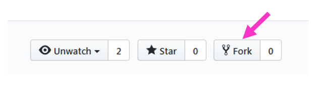

## 3. Clone the repo

1. Clone the repo

copy the URL

[figure not shown]

## 3. Clone the repo

2. Open GitKraken

*Clone with URL*

Where will it live on your local machine? It’s own folder, with no other RProjects

[figure not shown]

## 4. Provide script feedback

- Open `RProj` in your local (i.e., on your machine)
- Find the .qmd document you will be reviewing
  - it should be a .qmd document
- Make your edits/comments
  1. edit code as you like
  2. include a comment for each edit!
  3. Provide comments in code **and/or** text (`Ctrl/Command + Shift + C`)
- Commit as you go (if you are working on this across sessions/days)
- Push **only when you are finished**

## 5. commit & push

Once you have provided comments and code suggestions to the script

- save the changes
- go to GitKraken
- commit
- push

1. Navigate back to the (host) GitHub repo
2. Click “Pull requests”

[figure not shown]

3. Click “New pull request”

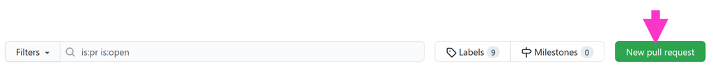

## 6. Create Pull Request (PR)

4. Click *“Compare across forks”*

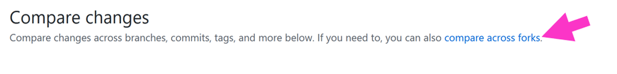

Use drop-downs so that:

- **left** = `host` repo
- **right** = `your` repo

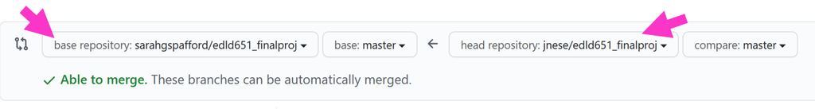

. . .

You will be able view the changes you made to the .qmd document

## 6. Create Pull Request (PR)

5. Click *“Create pull request”*

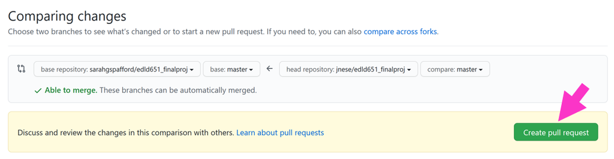

## 6. Create Pull Request (PR)

Write a brief summary list of the PR that includes

- >= 3 strengths
- >= 1 thing you learned
- 1 to 3 three areas of improvement
- **Use markdown formatting**
  - headers
  - lists
  - bold/italics

[figure not shown]

## 6. Create Pull Request (PR)

6. Click *“Create pull request”* when you’re done

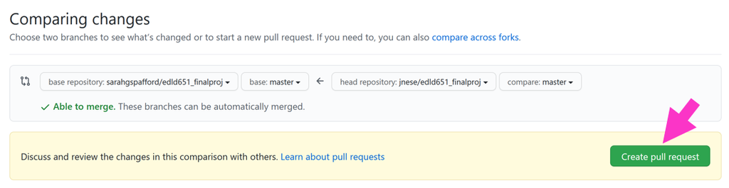

## 6. Create Pull Request (PR)

Recap

3. Navigate back to the (host) GitHub repo
4. Click *“Pull requests”*
5. Click *“New pull request”*
6. Click *“Compare across forks”*
   - Use drop-downs so that:
     - Host repo is on the left, your repo is on the right
   - View changes!
7. Click *“Create pull request”*
   - Write brief summary list of the PR that includes
     - >= 3 strengths
     - >= 1 thing you learned
     - 1 to 3 three areas of improvement
     - **Use markdown formatting, headers, or list!**
8. Click *“Create pull request”*

## Reviewing your PRs

You will get an email from GitHub

1. Click on first link, for PR
2. Click *“Commits”* tab
3. Click on *“File changes”* to see changes
4. Copy/paste all desired changes
5. Don’t close *“Close PR”* just yet; I want to review

# Next time

## Before next class

- Final Project
  - Final Project: Peer Review of Script
  - Final Project: Presentations - email me your content before class
- Homework
  - **Homework 10**
- Ask Me Anything (AMA)
  - R stuff
  - Professional/Career stuff